# Covid Analysis

22 Nov 2020

### Load Data

The data can be found at covid19ireland-geohive.hub.arcgis.com, specifically:

- [Test Data](https://covid19ireland-geohive.hub.arcgis.com/datasets/f6d6332820ca466999dbd852f6ad4d5a_0?geometry=129.375%2C-76.680%2C-129.375%2C76.680)
- [Hospital Cases](https://covid19ireland-geohive.hub.arcgis.com/datasets/fe9bb23592ec4142a4f4c2c9bd32f749_0?geometry=129.375%2C-76.680%2C-129.375%2C76.680)
- [ICU](https://covid19ireland-geohive.hub.arcgis.com/datasets/c8208a0a8ff04a45b2922ae69e9b2206_0)
- [Profile](https://opendata-geohive.hub.arcgis.com/datasets/d8eb52d56273413b84b0187a4e9117be_0)

The data can be loaded using the `read_csv` function from the `readr` package. When loading the data the date column can be changed to a date type by using `as.Date`, this makes it easier to sort and filter by date.

```r
library(readr)
library(dplyr)

# LaboratoryLocalTimeSeriesHistoricView
testing_csv <-
  read_csv("http://opendata-geohive.hub.arcgis.com/datasets/f6d6332820ca466999dbd852f6ad4d5a_0.csv?outSR={%22latestWkid%22:3857,%22wkid%22:102100}") %>%
  mutate(DateStamp = as.Date(Date_HPSC))

# Covid19AcuteHospitalHistoricSummaryOpenData
hospital_csv <-
  read_csv("http://opendata-geohive.hub.arcgis.com/datasets/fe9bb23592ec4142a4f4c2c9bd32f749_0.csv?outSR={%22latestWkid%22:4326,%22wkid%22:4326}")  %>%
  mutate(DateStamp = as.Date(Date))

# ICUBISHistoricTimelinePublicView
icu_csv <-
  read_csv("https://opendata.arcgis.com/datasets/c8208a0a8ff04a45b2922ae69e9b2206_0.csv") %>%
  mutate(DateStamp = as.Date(extract))

# CovidStatisticsProfileHPSCIrelandOpenData
profile_csv <-
  read_csv("https://opendata.arcgis.com/datasets/d8eb52d56273413b84b0187a4e9117be_0.csv") %>%
  mutate(DateStamp = as.Date(StatisticsProfileDate))
```

```r
cat("### Tidy and Merge Data

The 3 datasets can be joined together using the `left_join` function.

Extra statistics can also be calculated, e.g. the number of daily positive tests can be calculated by taking `Positive - lag(Positive)`. The `lag` function returns the previous value for a vector, therefore `Positive - lag(Positive)` will calculate today's value minus yesterday's value.

The `rollsum` function calculates a rolling total, the argument `k = 14` tells the function to calculate 14 day totals.")
```

### Tidy and Merge Data

The 3 datasets can be joined together using the `left_join` function.

Extra statistics can also be calculated, e.g. the number of daily positive tests can be calculated by taking `Positive - lag(Positive)`. The `lag` function returns the previous value for a vector, therefore `Positive - lag(Positive)` will calculate today’s value minus yesterday’s value.

The `rollsum` function calculates a rolling total, the argument `k = 14` tells the function to calculate 14 day totals.

```r
# library(zoo)
my_rolling_sum <- function(x, n_days = 14) zoo::rollsum(x - lag(x), k = n_days, align = "right", fill = NA)

covid_tidy <-
  testing_csv %>%
  arrange(DateStamp) %>%
  # select(DateStamp, TotalLabs, Positive, Hospitals) %>%
  transmute(DateStamp,
         daily_labs = TotalLabs - lag(TotalLabs),
         daily_positive = Positive - lag(Positive),
         rolling14_labs = my_rolling_sum(TotalLabs),
         rolling14_positive = my_rolling_sum(Positive),
         roling14_percentage = 100*(rolling14_positive/rolling14_labs)) %>%
  left_join(hospital_csv %>%
               arrange(DateStamp) %>%
               select(DateStamp,
                      hospital_cases = SUM_number_of_confirmed_covid_1,
                      hospital_new = SUM_no_new_admissions_covid19_p,
                      hospital_discharge = SUM_no_discharges_covid19_posit),
            by = "DateStamp") %>%
  left_join(icu_csv %>%
              select(DateStamp,
                     icu_cases = ncovidconf,
                     icu_new = adcconf),
            by = "DateStamp")
```

Summaries of the data can now be calculated, such as the statistics on a month by month basis.

```r
covid_table <-
  covid_tidy %>%
  mutate(month = format(DateStamp, "%m"), month_name = format(DateStamp, "%B")) %>%
  group_by(month, month_name) %>%
  summarise(total_tests = sum(daily_labs, na.rm = T),
            total_positive = sum(daily_positive, na.rm = T),
            no_obs = length(daily_labs),
            new_hospital = sum(hospital_new, na.rm = T),
            new_icu = sum(icu_new, na.rm = T)) %>%
  mutate(`% Positive` = paste0(round(100*(total_positive/total_tests), 2), "%")) %>%
  select(Month = month_name, `No. of Days Data` = no_obs,
         Tests = total_tests, Positive = total_positive, `% Positive`,
         `Hospital Admissions` = new_hospital, `ICU Admissions` = new_icu)

t(covid_table[,-1])
```

|  | March | April | May | June | July | August | September | October | November |
| --- | --- | --- | --- | --- | --- | --- | --- | --- | --- |
| No. of Days Data | 14 | 30 | 31 | 30 | 31 | 31 | 30 | 31 | 21 |
| Tests | 24343 | 138846 | 174979 | 85177 | 203235 | 206960 | 341171 | 453611 | 234866 |
| Positive | 3262 | 19426 | 4901 | 611 | 681 | 2867 | 7589 | 25938 | 8583 |
| % Positive | 13.4% | 13.99% | 2.8% | 0.72% | 0.34% | 1.39% | 2.22% | 5.72% | 3.65% |
| Hospital Admissions | 0 | 972 | 419 | 85 | 35 | 65 | 177 | 669 | 313 |
| ICU Admissions | 0 | 151 | 59 | 13 | 5 | 9 | 31 | 77 | 52 |

### Prepare for Plotting

In order to make it easier to plot multiple variables using `ggplot2`, the data must be transformed from ‘wide’ to ‘long’. The current format of the data has 1 row for each date, once transformed the data will have a row for each date and variable combination.

#### Current Format (Wide)

| DateStamp | hospital_cases | icu_cases | rolling14_positive | roling14_percentage |
| --- | --- | --- | --- | --- |
| 2020-11-21 | 275 | 32 | 5262 | 3.4210 |
| 2020-11-20 | 287 | 33 | 5444 | 3.4993 |
| 2020-11-19 | 290 | 32 | 5558 | 3.5952 |
| 2020-11-18 | 274 | 33 | 5676 | 3.6906 |
| 2020-11-17 | 273 | 34 | 5904 | 3.8380 |
| 2020-11-16 | 276 | 34 | 5931 | 3.8426 |

#### Transformed Format (Long)

The `pivot_longer` function will transform the data to a long format. The statistics present in the new data can be chosen from the current columns.

```r
stats_key <-
  c("hospital_cases" = "Cases in Hospitals",
    "icu_cases" = "Cases in ICU",
    "rolling14_positive" = "Positive Tests (14 Day Total)",
    "roling14_percentage" = "% Positive Tests (14 Day Total)")

testing_plot_data <-
  covid_tidy %>%
  tidyr::pivot_longer(cols = names(stats_key),
                      names_to = "stat", values_to = "value") %>%
  mutate(stat = recode_factor(stat, !!!stats_key, .ordered = TRUE))
```

[output not shown]

## Graphs

```r
key_dates <-
  data.frame(event = c("First Lockdown", "Easing Restrictions", "Phase 3 Easing", "Midlands Lockdown",  "Dublin L3",  "Level 3", "Level 5"),
             datestamp = c("2020-03-15", "2020-05-18",          "2020-06-29",     "2020-08-07",        "2020-09-18", "2020-10-04", "2020-10-19")) %>%
  mutate(datestamp = as.Date(datestamp))

key_dates_2w <-
  key_dates %>%
  mutate(datestamp = datestamp + 14)
```

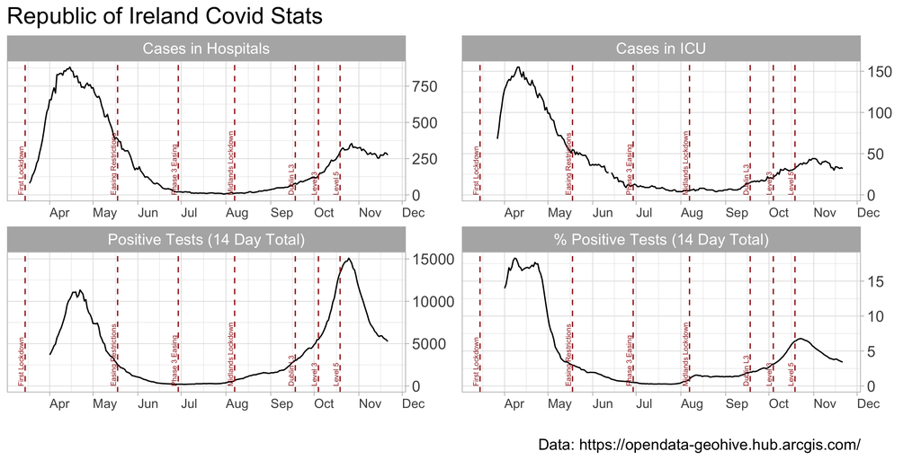

```r
library(ggplot2)

covid_plot <-
  testing_plot_data %>%
  ggplot() +
  geom_line(aes(x = DateStamp, y = value)) +
  geom_vline(data = key_dates, aes(xintercept = datestamp), linetype = 2, colour = "brown") +
  # geom_vline(data = key_dates_2w, aes(xintercept = datestamp), linetype = 3, colour = "red", size = 0.5) +
  geom_text(data = key_dates, mapping = aes(label = event, y = 0, x = datestamp),
            angle = 90, hjust = -0, vjust = -0.3, size = 2, colour = "brown") +
  # Change y scale to right and have all plots begin scale at 0
  scale_y_continuous(position = "right", limits = c(0, NA)) +
  # Show each month on the x axis
  scale_x_date(date_breaks = "1 month", date_labels = "%b", ) +
  # Create individual plots for each statistic
  facet_wrap(~stat, ncol = 2, scales = "free") +
  # Add labels to the plot
  labs(x = "", y = "",
       title = "Republic of Ireland Covid Stats",
       caption = 'Data: https://opendata-geohive.hub.arcgis.com/') +
  theme_light() +
  theme(text = element_text(size = 15),
        axis.text.x = element_text(size = 10, angle = 0, hjust = 0))

covid_plot
```

The plot can be saved locally using `ggsave`

```r
ggsave(file = paste0("~/Desktop/", Sys.Date(), "_covid_roi.png"),
       plot = covid_plot, width = 7, height = 5, units = "in")
```

#### Recent Data Only

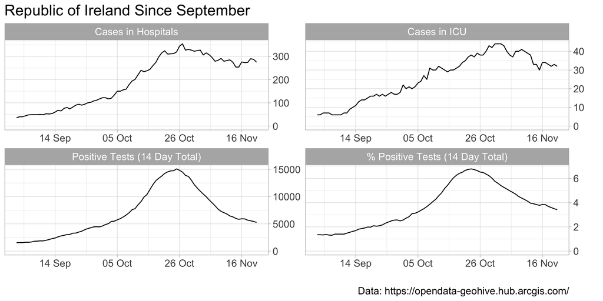

```r
covid_plot_aug <-
  testing_plot_data %>%
  # remove any data before "2020-08-01"
  filter(DateStamp >= start_date) %>%
  ggplot(aes(x = DateStamp, y = value)) +
  geom_line() +
  scale_y_continuous(position = "right", limits = c(0, NA)) +
  scale_x_date(date_breaks = "3 week", date_labels = "%d %b") +
  facet_wrap(~stat, ncol = 2, scales = "free") +
  labs(x = "", y = "",
       title = paste0("Republic of Ireland Since ", format(start_date, "%B")),
       caption = 'Data: https://opendata-geohive.hub.arcgis.com/') +
  theme_light() +
  theme(text = element_text(size = 15))

covid_plot_aug
```

## Breakdown of Cases

```r
by_age_14day <-
  profile_csv %>%
  select(DateStamp, starts_with("Aged")) %>%
  arrange(DateStamp) %>%
  # Calculate rolling 14 day totals of all columns beginning with 'Aged'
  mutate(across(starts_with("Aged"), my_rolling_sum)) %>%
  # Pivot table to long format for columns beginning with 'Aged'
  tidyr::pivot_longer(cols = starts_with("Aged"),
                      names_to = "Age_Group", values_to = "Cases")
```

| DateStamp | Age_Group | Cases |
| --- | --- | --- |
| 2020-11-19 | Aged1 | 120 |
| 2020-11-19 | Aged1to4 | 96 |
| 2020-11-19 | Aged5to14 | 546 |
| 2020-11-19 | Aged15to24 | 959 |
| 2020-11-19 | Aged25to34 | 840 |
| 2020-11-19 | Aged35to44 | 841 |

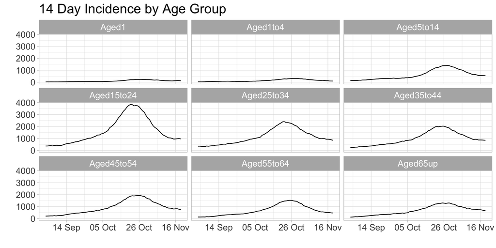

```r
by_age_14day %>%
  filter(DateStamp > start_date) %>%
  # Change order in which the age groups will appear for plot
  mutate(Age_Group = forcats::fct_relevel(Age_Group, unique(.$Age_Group))) %>%
  # Begin plot
  ggplot(aes(x = DateStamp, y = Cases)) +
  geom_line() +
  # Create a single plot for each age group
  facet_wrap(~Age_Group) +
  # Specify the breaks for dates
  scale_x_date(date_breaks = "3 week", date_labels = "%d %b") +
  labs(title = "14 Day Incidence by Age Group",
       x = "", y = "") +
  theme_light() +
  theme(text = element_text(size = 16))
```

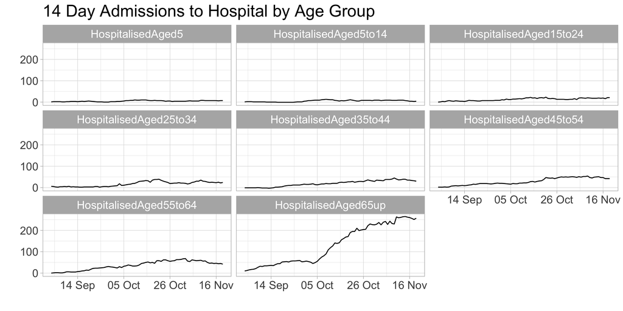

```r
# same as above but with "HospitalisedAged"
profile_csv %>%
  select(DateStamp, starts_with("HospitalisedAged")) %>%
  arrange(DateStamp) %>%
  mutate(across(starts_with("HospitalisedAged"), my_rolling_sum)) %>%
  tidyr::pivot_longer(cols = starts_with("HospitalisedAged"),
                      names_to = "Age_Group", values_to = "Cases") %>%
  filter(DateStamp > start_date) %>%
  mutate(Age_Group = forcats::fct_relevel(Age_Group, unique(.$Age_Group))) %>%
  ggplot(aes(x = DateStamp, y = Cases)) +
  geom_line() +
  facet_wrap(~Age_Group) +
  scale_x_date(date_breaks = "3 week", date_labels = "%d %b") +
  labs(title = "14 Day Admissions to Hospital by Age Group",
       x = "", y = "") +
  theme_light() +
  theme(text = element_text(size = 16))
```

## Combining Cases and Hospital Admissions

```r
case_and_hospital_14day <-
  profile_csv %>%
  select(DateStamp, starts_with(c("Aged","HospitalisedAged"))) %>%
  # use mutates to consolidate case groupings to match hospital groups
  mutate(Aged4 = Aged1 + Aged1to4, HospitalisedAged4 = HospitalisedAged5, .keep = "unused") %>%
  mutate(across(starts_with(c("Aged","HospitalisedAged")), my_rolling_sum)) %>%
  tidyr::pivot_longer(cols = starts_with(c("Aged","HospitalisedAged")),
                      names_to = "Age_Group", values_to = "Cases")
```

| DateStamp | Age_Group | Cases |
| --- | --- | --- |
| 2020-11-19 | Aged4 | 216 |
| 2020-11-19 | HospitalisedAged4 | 7 |
| 2020-11-18 | Aged4 | 230 |
| 2020-11-18 | HospitalisedAged4 | 7 |
| 2020-11-17 | Aged4 | 233 |
| 2020-11-17 | HospitalisedAged4 | 6 |

```r
case_and_hospital_14day <-
  case_and_hospital_14day %>%
  # create new variable 'Hospital' to denote if the row is a value for hospital
  # also remove Hospitalised from hospital age groups to match the cases grouping
  mutate(Hospital = if_else(stringr::str_detect(Age_Group, "Hospital"), "Hospitalised", "Total"),
         Age_Group = stringr::str_replace(Age_Group, "Hospitalised", ""))
```

| DateStamp | Age_Group | Cases | Hospital |
| --- | --- | --- | --- |
| 2020-11-19 | Aged4 | 216 | Total |
| 2020-11-19 | Aged4 | 7 | Hospitalised |
| 2020-11-18 | Aged4 | 230 | Total |
| 2020-11-18 | Aged4 | 7 | Hospitalised |
| 2020-11-17 | Aged4 | 233 | Total |
| 2020-11-17 | Aged4 | 6 | Hospitalised |

```r
case_and_hospital_14day <-
  case_and_hospital_14day %>%
  # pivot on the new 'Hospital' variable
  tidyr::pivot_wider(names_from = Hospital, values_from = Cases)
```

| DateStamp | Age_Group | Total | Hospitalised |
| --- | --- | --- | --- |
| 2020-11-19 | Aged4 | 216 | 7 |
| 2020-11-18 | Aged4 | 230 | 7 |
| 2020-11-17 | Aged4 | 233 | 6 |
| 2020-11-16 | Aged4 | 242 | 7 |
| 2020-11-15 | Aged4 | 238 | 7 |

#### Plot

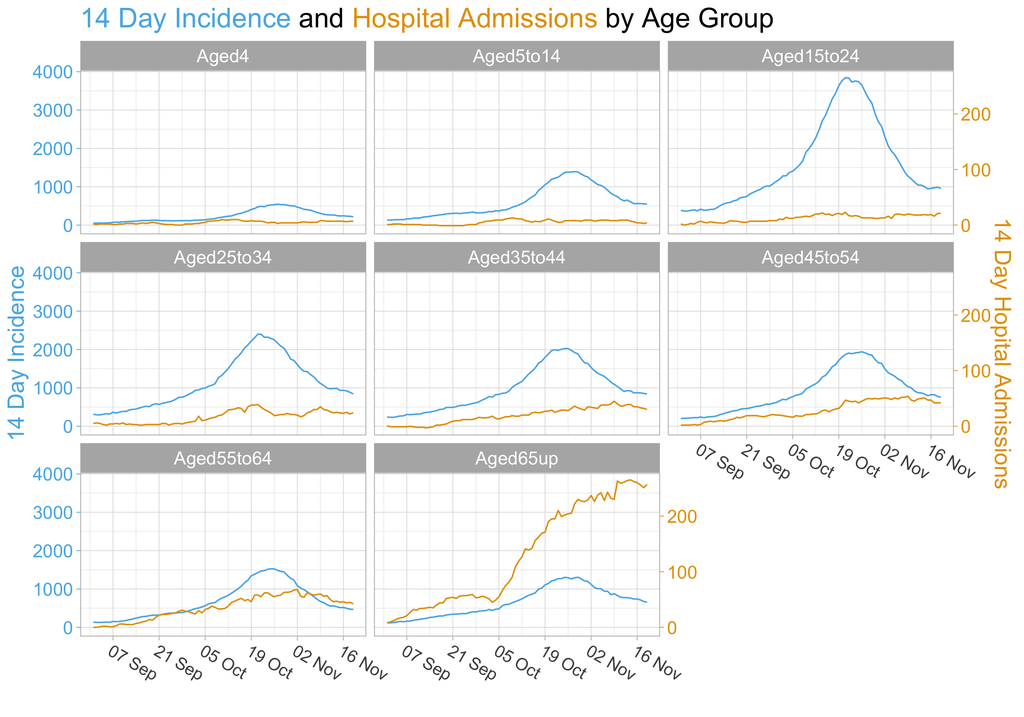

```r
# scl is used to scale the lines for the two groups
# We want the max values for both to be the limit for each
scl <-
  case_and_hospital_14day  %>%
  filter(DateStamp >= start_date) %>%
  summarise(max_tot = max(Total, na.rm = T),
            max_hospital = max(Hospitalised, na.rm = T)) %>%
  mutate(scale = max_tot/max_hospital) %>%
  pull(scale)


# cols are colours which are colourblind friendly
cols <-
  c("#E69F00", "#56B4E9", "#009E73",
    "#F0E442", "#0072B2", "#D55E00", "#CC79A7")

# library(ggtext)

case_and_hospital_14day  %>%
  filter(DateStamp >= start_date) %>%
  mutate(Age_Group = forcats::fct_relevel(Age_Group, c("Aged4", "Aged5to14"))) %>%
  ggplot() +
  # Add line for total cases
  geom_line(aes(x = DateStamp, y = Total, colour = "Total Cases")) +
  # Add line for hospital admissions
  geom_line(aes(x = DateStamp, y = Hospitalised*scl, colour = "Hospitalised")) +
  # Create a separate plot for each group
  facet_wrap(~Age_Group) +
  # sec_axis scales the hospital admissions data and adds axis labels on the right hand side
  scale_y_continuous(sec.axis = sec_axis(~./scl, name = "14 Day Hopital Admissions")) +
  scale_x_date(date_breaks = "2 weeks", date_labels = "%d %b") +
  # Use the custom colours
  scale_colour_manual(values = cols) +
  labs(title = paste0("<span style='color:", cols[2],";'>14 Day Incidence</span>"," and ",
                      "<span style='color:", cols[1],";'>Hospital Admissions</span>"," by Age Group"),
    # title = "14 Day Incidence and Hospital Admissions by Age Group",
       x = "", y = "14 Day Incidence", colour= "") +
  theme_light() +
  # Change elements of the plot to match the colours of the lines
  theme(plot.title = ggtext::element_markdown(lineheight = 1.1),
        legend.position = "none",
        legend.margin=margin(-10,0,0,0),
        axis.text.y.right=element_text(colour=cols[1]),
        axis.ticks.y.right=element_line(colour=cols[1]),
        axis.title.y.right=element_text(colour=cols[1]),
        axis.text.y=element_text(colour=cols[2]),
        axis.ticks.y=element_line(colour=cols[2]),
        axis.title.y=element_text(colour=cols[2]),
        text = element_text(size = 16),
        axis.text.x = element_text(size = 12, angle = -30, hjust = 0))
```

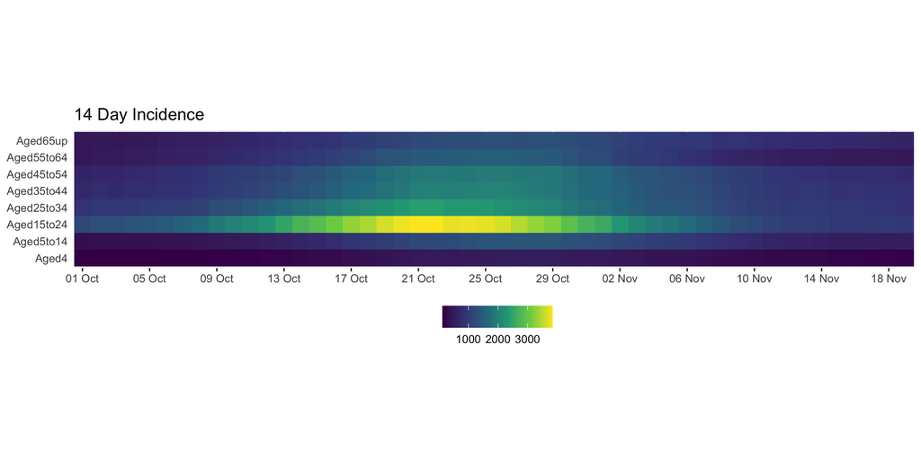

```r
case_and_hospital_14day  %>%
  filter(DateStamp >= (start_date + 30)) %>%
  mutate(Age_Group = forcats::fct_relevel(Age_Group, c("Aged4", "Aged5to14"))) %>%
  ggplot() +
  # Add line for total cases
  geom_tile(aes(x = DateStamp, y = Age_Group, fill = Total), size = 0.1) +
  # scale_fill_viridis_c() +
  # scale_fill_distiller(palette = "RdYlGn", limits = c(0, NA)) +
  scale_fill_viridis_c() +
  scale_x_date(date_breaks = "4 days", date_labels = "%d %b", expand = c(0,0)) +
  coord_equal() +
  # theme_light() +
  # ggthemes::theme_tufte(base_family="Helvetica") +
  labs(x = NULL, y = NULL, fill = NULL,
       title = "14 Day Incidence") +
  theme(axis.ticks.y=element_blank(),
        # axis.text.x = element_text(hjust = 0),
        legend.position = "bottom")
```

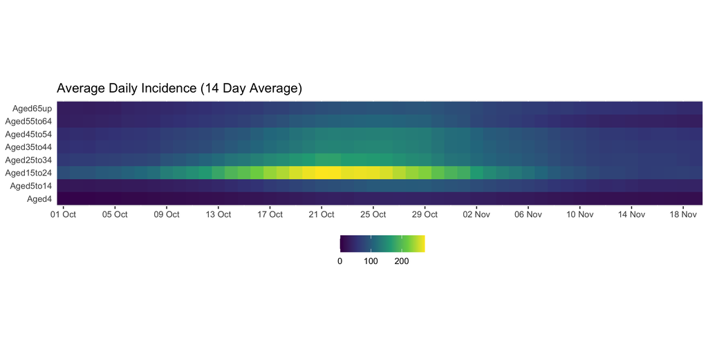

```r
case_and_hospital_14day  %>%
  filter(DateStamp >= (start_date + 30)) %>%
  mutate(Age_Group = forcats::fct_relevel(Age_Group, c("Aged4", "Aged5to14")),
         Total = Total/14) %>%
  ggplot() +
  # Add line for total cases
  geom_tile(aes(x = DateStamp, y = Age_Group, fill = Total), size = 0.1) +
  # scale_fill_viridis_c() +
  # scale_fill_distiller(palette = "RdYlGn", limits = c(0, NA)) +
  scale_fill_viridis_c(limits = c(0, NA)) +
  # viridis::scale_fill_viridis() +
  scale_x_date(date_breaks = "4 days", date_labels = "%d %b", expand = c(0,0)) +
  coord_equal() +
  # theme_light() +
  # ggthemes::theme_tufte(base_family="Helvetica") +
  labs(x = NULL, y = NULL, fill = NULL,
       title = "Average Daily Incidence (14 Day Average)") +
  theme(axis.ticks.y=element_blank(),
        # axis.text.x = element_text(hjust = 0),
        legend.position = "bottom")
```

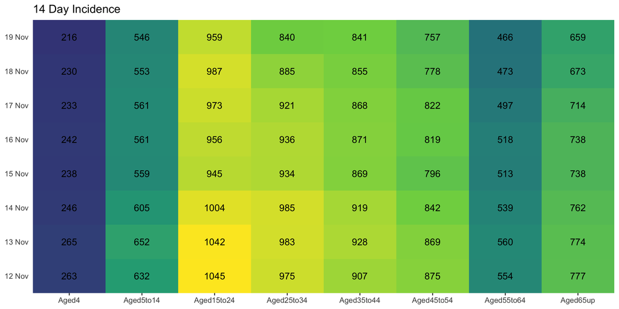

```r
  # # Add line for hospital admissions
  # geom_line(aes(x = DateStamp, y = Hospitalised*scl, colour = "Hospitalised")) +
  # # Create a separate plot for each group
  # facet_wrap(~Age_Group) +
  # # sec_axis scales the hospital admissions data and adds axis labels on the right hand side
  # scale_y_continuous(sec.axis = sec_axis(~./scl, name = "14 Day Hopital Admissions")) +
  # scale_x_date(date_breaks = "2 weeks", date_labels = "%d %b") +
  # # Use the custom colours
  # scale_colour_manual(values = cols) +
  # labs(title = paste0("<span style='color:", cols[2],";'>14 Day Incidence</span>"," and ",
  #                     "<span style='color:", cols[1],";'>Hospital Admissions</span>"," by Age Group"),
  #   # title = "14 Day Incidence and Hospital Admissions by Age Group",
  #      x = "", y = "14 Day Incidence", colour= "") +
  # theme_light()



case_and_hospital_14day  %>%
  filter(DateStamp >= Sys.Date() - 10) %>%
  mutate(Age_Group = forcats::fct_relevel(Age_Group, c("Aged4", "Aged5to14"))) %>%
  ggplot() +
  # Add line for total cases
  geom_tile(aes(y = DateStamp, x = Age_Group, fill = Total), size = 0.1) +
  geom_text(aes(y = DateStamp, x = Age_Group, label = Total)) +
  # scale_fill_viridis_c() +
  # scale_fill_distiller(palette = "RdYlGn", limits = c(0, NA)) +
  scale_fill_viridis_c(limits = c(0, NA)) +
  scale_y_date(date_breaks = "1 days", date_labels = "%d %b", expand = c(0,0)) +
  scale_x_discrete(expand = c(0,0)) +
  # coord_equal() +
  # theme_light() +
  # ggthemes::theme_tufte(base_family="Helvetica") +
  labs(x = NULL, y = NULL, fill = NULL,
       title = "14 Day Incidence") +
  theme(axis.ticks.y=element_blank(),
        # axis.text.x = element_text(hjust = 0),
        legend.position = "none")
```

## Origin of Transmission

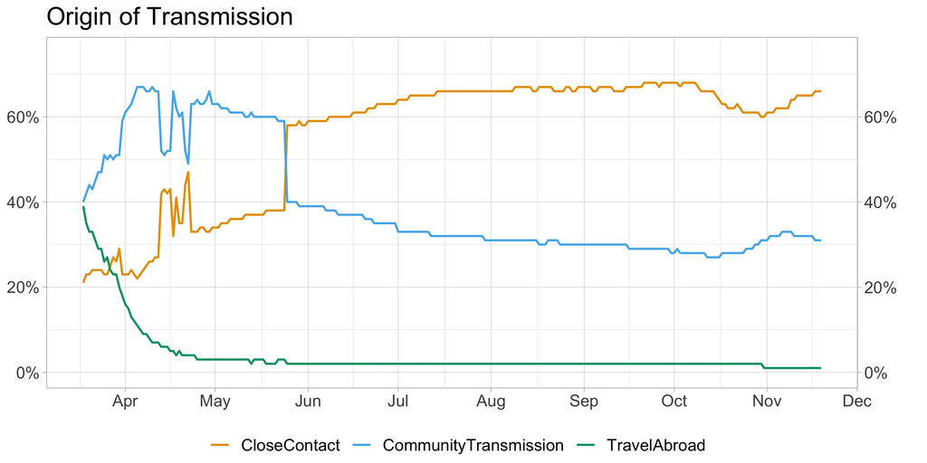

```r
profile_csv %>%
  mutate(NoData = 100 - (CommunityTransmission + CloseContact + TravelAbroad),
         NoData = if_else(NoData < 0, 0, NoData)) %>%
  # select(DateStamp, CommunityTransmission, CloseContact, TravelAbroad, NoData) %>%
  tidyr::pivot_longer(cols = c(CommunityTransmission, CloseContact, TravelAbroad),#, NoData
                      names_to = "Origin", values_to = "Perc") %>%
  tidyr::drop_na() %>%
  # mutate(Origin = forcats::fct_relevel(Origin, unique(.$Origin))) %>%
  ggplot(aes(x = DateStamp, y = Perc, colour = Origin)) +
  geom_line(size = 0.8) +
  scale_y_continuous(labels = function(x) paste0(x, "%"), limits = c(0, 75), position = "right",
                     sec.axis = sec_axis(~., labels = function(x) paste0(x, "%"))) +
  scale_x_date(date_breaks = "1 month", date_labels = "%b") +
  scale_colour_manual(values=cols) +
  labs(title = "Origin of Transmission ",
       y = "", x = "", colour= "") +
  theme_light() +
  theme(legend.margin=margin(-10,0,0,0),
        text = element_text(size = 16),
        legend.position = "bottom") # legend.title=element_blank()
```